# Case study

Zamberger Bernd, Koch Mathias

# Introduction and Setup

In this project we will make heavy use of the dada2 package from [the DADA2-Github](https://benjjneb.github.io/dada2), and there are some requirements listed (see ‘Starting point’ from the tutorial).

The requirements are - [X] Samples have been demultiplexed, i.e. split into individual per-sample fastq files. - [ ] Non-biological nucleotides have been removed, e.g. primers, adapters, linkers, etc. - [ ] If paired-end sequencing data, the forward and reverse fastq files contain reads in matched order.

## Environment Preperations, Loading the DADA2 Package and Data Import

```r
# Set working directory (use full path for this, for further paths use relative paths)
# save the working directory as variable
project_path<-'/proj/courses/2023_mg/cooler/Case_Study_BZ_MK'
setwd(project_path)

# Load libraries
library(dada2)
packageVersion("dada2") # check the version
```

```
## [1] '1.28.0'
```

```r
# Read in Data
raw_reads <- "./raw_data/"
list.files(raw_reads) # Overview of data
```

```
##  [1] "1-H_S79_L001_R1_001.fastq"
##  [2] "1-H_S79_L001_R2_001.fastq"
##  [3] "10-H_S92_L001_R1_001.fastq"
##  [4] "10-H_S92_L001_R2_001.fastq"
##  [5] "11-H_S9_L001_R1_001.fastq"
##  [6] "11-H_S9_L001_R2_001.fastq"
##  [7] "12-H_S21_L001_R1_001.fastq"
##  [8] "12-H_S21_L001_R2_001.fastq"
##  [9] "13-H_S33_L001_R1_001.fastq"
## [10] "13-H_S33_L001_R2_001.fastq"
## [11] "14-H_S45_L001_R1_001.fastq"
## [12] "14-H_S45_L001_R2_001.fastq"
## [13] "15-H_S57_L001_R1_001.fastq"
## [14] "15-H_S57_L001_R2_001.fastq"
## [15] "2-H_S91_L001_R1_001.fastq"
```

[output cut: 25 more lines]

### Separation of the samples in Forward and Reverse Reads based on their Names.

```r
fnFs <- sort(list.files(raw_reads, pattern="_R1_001.fastq", full.names = TRUE))
fnRs <- sort(list.files(raw_reads, pattern="_R2_001.fastq", full.names = TRUE)) # Extract sample names, assuming filenames have format: SAMPLENAME_XXX.fastq
sample.names <- sapply(strsplit(basename(fnFs), "_"), `[`, 1)
```

### Inspection and control of the quality Profiles

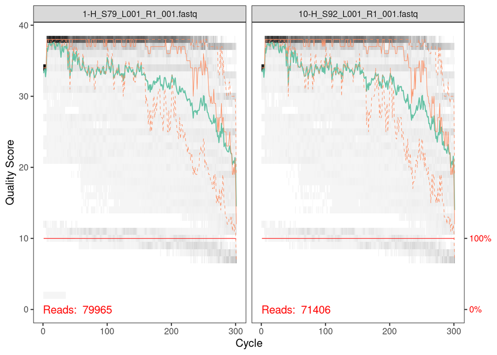

```r
plotQualityProfile(fnFs[1:2]) # first two samples forward reads, they are representative
```

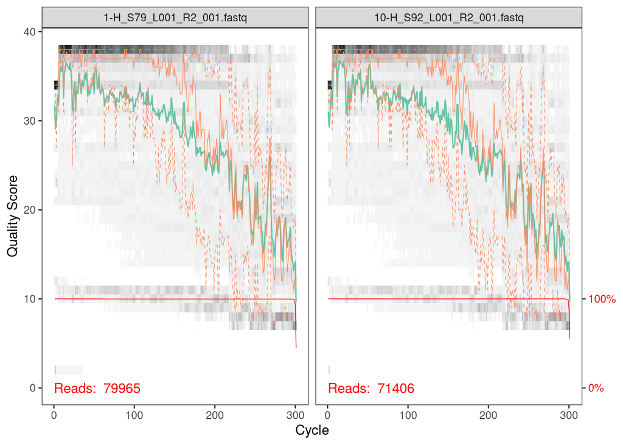

```r
plotQualityProfile(fnRs[1:2]) # representative reverse reads of two samples
```

The Quality Profiles include multiple information and allows for the adjustment of the parameters to accommodate the data.

It includes * a grey-scale heat map of the frequency of each quality score at each base position * the mean quality score (green line), as well as the quality score distribution (orange lines) at that position.

Saving the plots as files, to use them for interpretation.

```r
# Opening the graphical device
dev='pdf'
pdf("./figures/QualityProfile_F_1and2.pdf"); plotQualityProfile(fnFs[1:2])
pdf("./figures/QualityProfile_R_1and2.pdf"); plotQualityProfile(fnRs[1:2])
# Closing the graphical device
dev.off()
```

### Storage of filtered reads in a seperate directory

```r
#dir.create("./intermediate_results/") # creation of the neccessary directory , uncomment if neccessary
intermediate_results <- ("./intermediate_results/")
filtFs <- file.path(intermediate_results, "filtered_reads", paste0(sample.names, "_F_filt.fastq.gz"))
filtRs <- file.path(intermediate_results, "filtered_reads", paste0(sample.names, "_R_filt.fastq.gz"))
```

### imported of the sample names for future discrimination

```r
# Read in the Sample Names
names(filtFs) <- sample.names
names(filtRs) <- sample.names
```

## Quality Filtering and Trimming

The (modified) Arguments for the filterAndTrim() commmand: * fwd, filt, rev, filt.rev Objects (or Files) containing fastq files * truncLen Truncate reads after truncLen bases, here different lengths are specified for the forward and reverse reads * maxN Specifies the number of the maximum of unknown bases are allowed in the read (deprecated, since the DADA2 algorithm needs no Ns) * maxEE maximum number of expected errors, we set them relatively high, to allow more, but possibly errenous reads through the filter * truncQ (Optional). Default 2. Truncate reads at the first instance of a quality score less than or equal to truncQ.

- rm.phix
- compress
- multithread

by the sequencing center the illumina tags were removed and the samples demultiplexed but the primers (including ambigous bases were kept) these are removed in following code chunk

following primers were provided by the lecturers primer_fwd = AACMGGATTAGATACCCKG primer_rev = ACGTCRTCCCCDCCTTCCTC

```r
primer_fwd <- "AACMGGATTAGATACCCKG"
primer_rev <- "ACGTCRTCCCCDCCTTCCTC"

# primers will be removed with trimLeft command

out <- filterAndTrim(fnFs, filtFs, fnRs, filtRs, trimLeft = c(nchar(primer_fwd), nchar(primer_rev)), truncLen=c(250,200), maxN=0, maxEE=c(8,6), truncQ=2, rm.phix=TRUE, compress=TRUE, multithread=TRUE)#
  # this command needs to be revisited and improved, might trim to much
  # the filtered reads are saved in the 'out' object, following the nomenclature of the tutorial

head(out) # displays the first few lines of the object 'out'
```

```
##                            reads.in reads.out
## 1-H_S79_L001_R1_001.fastq     79965     66772
## 10-H_S92_L001_R1_001.fastq    71406     60648
## 11-H_S9_L001_R1_001.fastq     79258     66662
## 12-H_S21_L001_R1_001.fastq   102788     85108
## 13-H_S33_L001_R1_001.fastq   124167    109086
## 14-H_S45_L001_R1_001.fastq   175701    151263
```

Investigations in the ‘truncLen’ parameters: * The truncLen=c(150,130) which would be desirable, based on the mean Quality Profile - plots, are not feasible since then the forward and reverse reads are most often not overlapping for the merging of Pairs. * the tutorial suggests to relax the ‘maxEE’ parameter if to few reads are passed the filter, which were changed from maxEE=c(2,2) initially

If the parameters should relveal themselfs to be critically for the investigation, the tool called [figaro] (https://github.com/Zymo-Research/figaro#figaro) could be potentially used to help choose the truncation length parameters.

## Plot the Quality after trimming of primers and bad quality reads (incl. tailing)

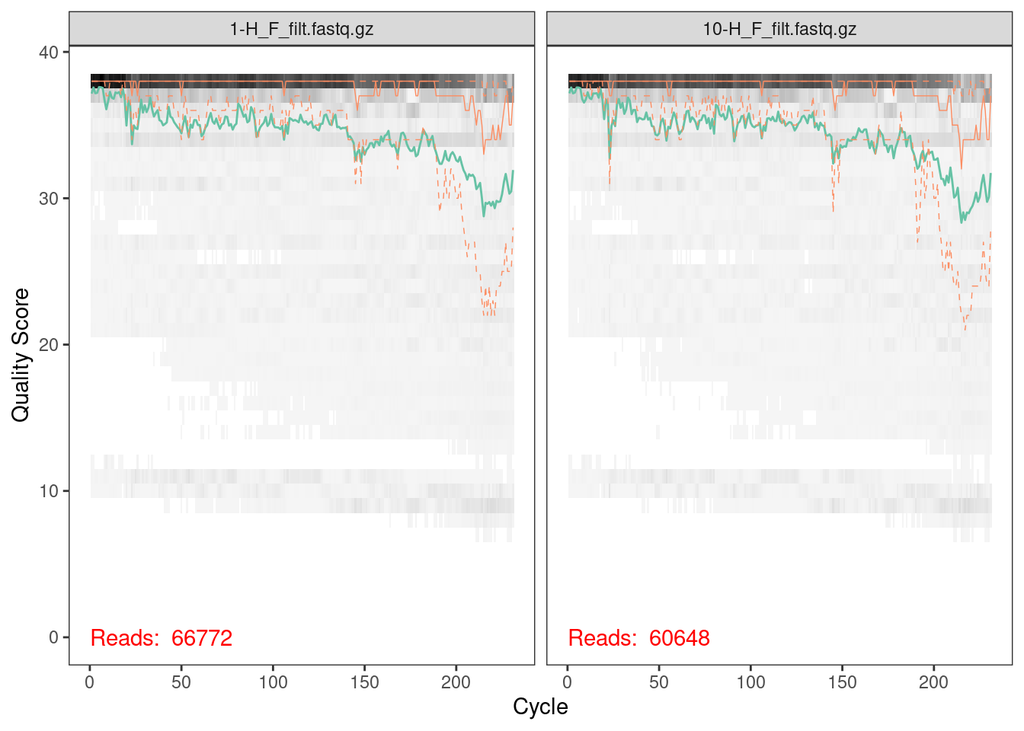

```r
plotQualityProfile(filtFs[1:2]) # first two samples forward reads, they are representative
```

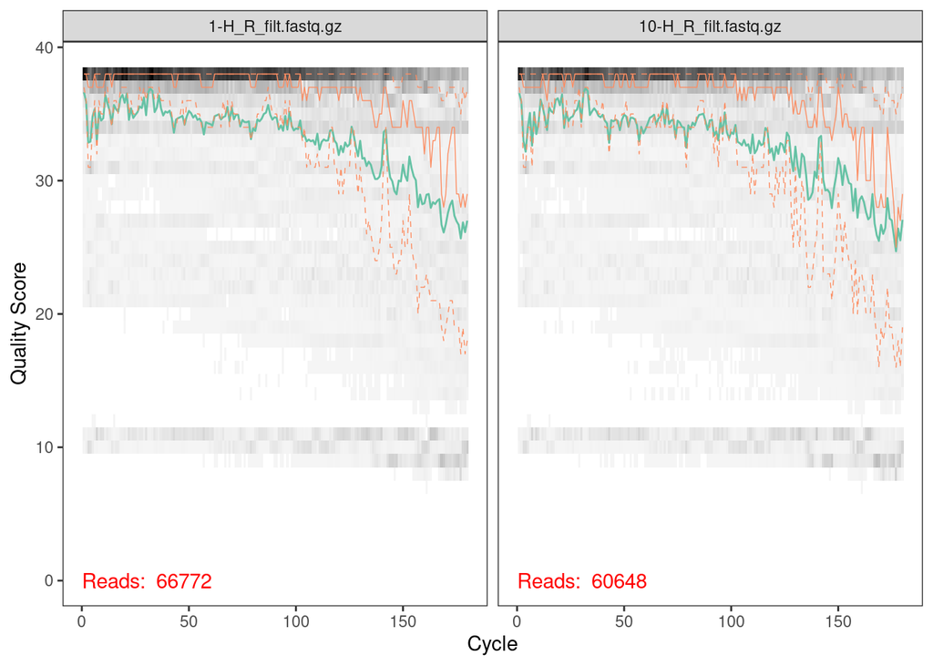

```r
plotQualityProfile(filtRs[1:2]) # representative reverse reads of two samples
```

# Saving the plots in files for later use.

```r
# Opening the graphical device
dev='pdf'
pdf("./figures/QualityProfile_F_1and2_trimmed.pdf"); plotQualityProfile(filtFs[1:2])
pdf("./figures/QualityProfile_R_1and2_trimmed.pdf"); plotQualityProfile(filtRs[1:2])
# Closing the graphical device
dev.off()
```

# Check error rates

The DADA2 algorithm includes a ‘learnErrors’ method, which alternates between sample inference and error rate estimation, until the two converge in a consistently manner. Since this step involves randomness, it is good practice to involve a set seed.

```r
set.seed(908)
errF <- learnErrors(filtFs, multithread=TRUE)
```

```
## 124633509 total bases in 539539 reads from 6 samples will be used for learning the error rates.
```

```r
errR <- learnErrors(filtRs, multithread=TRUE)
```

```
## 129196620 total bases in 717759 reads from 7 samples will be used for learning the error rates.
```

Plot observed and estimated error rates

plotErrors: This function plots the observed frequency of each transition (eg. A->C) as a function of the associated quality score. - nominalQ (Optional). Default FALSE. If TRUE, plot the expected error rates (red line) if quality scores exactly matched their nominal definition: Q = -10 log10(p_err)

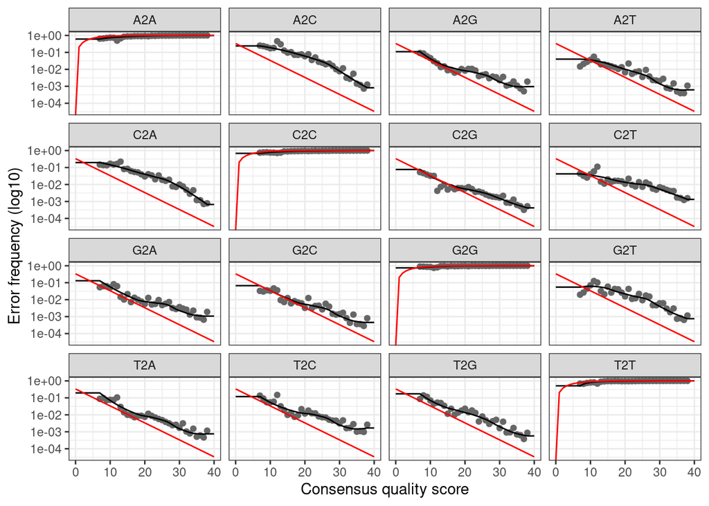

```r
plotErrors(errF, nominalQ=TRUE)
```

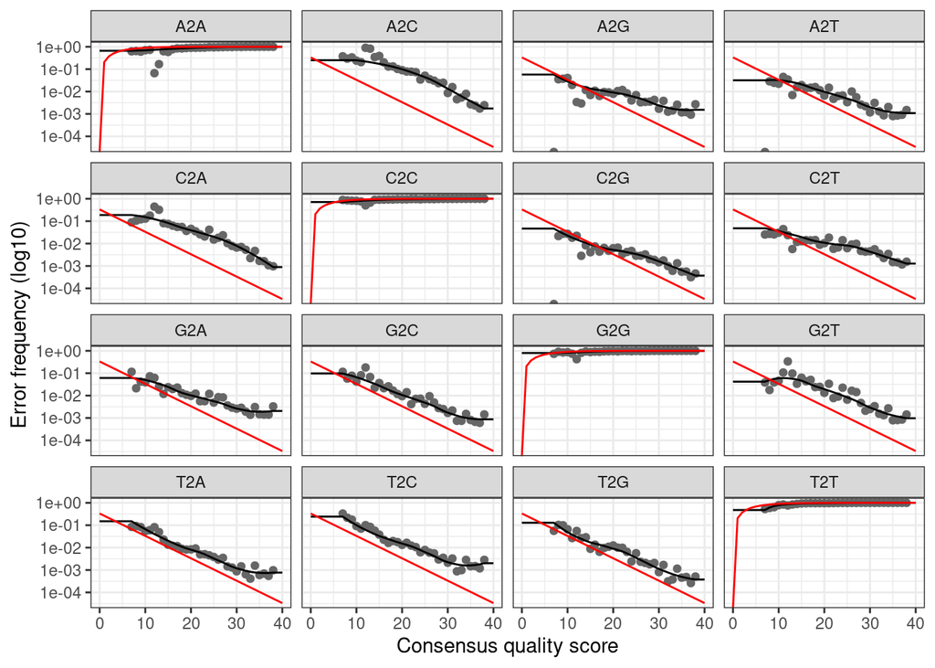

```r
plotErrors(errR, nominalQ=TRUE)
```

# Sample Inference Look through the samples to identify *unique* sequences with dada algorithm.

```r
dadaFs <- dada(filtFs, err=errF, multithread=TRUE)
```

```
## Sample 1 - 66772 reads in 29825 unique sequences.
## Sample 2 - 60648 reads in 26100 unique sequences.
## Sample 3 - 66662 reads in 32051 unique sequences.
## Sample 4 - 85108 reads in 37918 unique sequences.
## Sample 5 - 109086 reads in 46219 unique sequences.
## Sample 6 - 151263 reads in 70445 unique sequences.
## Sample 7 - 178220 reads in 81712 unique sequences.
## Sample 8 - 58286 reads in 28143 unique sequences.
## Sample 9 - 60231 reads in 30450 unique sequences.
## Sample 10 - 62777 reads in 31278 unique sequences.
## Sample 11 - 57982 reads in 27686 unique sequences.
## Sample 12 - 58816 reads in 26449 unique sequences.
## Sample 13 - 75967 reads in 36027 unique sequences.
## Sample 14 - 75159 reads in 41463 unique sequences.
## Sample 15 - 77223 reads in 38811 unique sequences.
## Sample 16 - 46172 reads in 23222 unique sequences.
## Sample 17 - 45545 reads in 23016 unique sequences.
## Sample 18 - 54775 reads in 25035 unique sequences.
```

```r
dadaRs <- dada(filtRs, err=errR, multithread=TRUE)
```

```
## Sample 1 - 66772 reads in 37646 unique sequences.
## Sample 2 - 60648 reads in 34585 unique sequences.
## Sample 3 - 66662 reads in 38856 unique sequences.
## Sample 4 - 85108 reads in 51006 unique sequences.
## Sample 5 - 109086 reads in 62208 unique sequences.
## Sample 6 - 151263 reads in 91549 unique sequences.
## Sample 7 - 178220 reads in 100680 unique sequences.
## Sample 8 - 58286 reads in 34893 unique sequences.
## Sample 9 - 60231 reads in 35499 unique sequences.
## Sample 10 - 62777 reads in 38851 unique sequences.
## Sample 11 - 57982 reads in 36375 unique sequences.
## Sample 12 - 58816 reads in 35065 unique sequences.
## Sample 13 - 75967 reads in 44926 unique sequences.
## Sample 14 - 75159 reads in 48446 unique sequences.
## Sample 15 - 77223 reads in 48379 unique sequences.
## Sample 16 - 46172 reads in 28485 unique sequences.
## Sample 17 - 45545 reads in 30209 unique sequences.
## Sample 18 - 54775 reads in 32771 unique sequences.
```

```r
dadaFs[[1]] #consistency check for the forward reads
```

```
## dada-class: object describing DADA2 denoising results
## 201 sequence variants were inferred from 29825 input unique sequences.
## Key parameters: OMEGA_A = 1e-40, OMEGA_C = 1e-40, BAND_SIZE = 16
```

```r
dadaRs[[1]] #consistency check for the reverse reads
```

```
## dada-class: object describing DADA2 denoising results
## 140 sequence variants were inferred from 37646 input unique sequences.
## Key parameters: OMEGA_A = 1e-40, OMEGA_C = 1e-40, BAND_SIZE = 16
```

```r
# Merge the paired reads (forward and reverse)

mergers <- mergePairs(dadaFs, filtFs, dadaRs, filtRs, verbose=TRUE)
```

```
## 60479 paired-reads (in 711 unique pairings) successfully merged out of 64226 (in 1655 pairings) input.
```

```
## 55086 paired-reads (in 452 unique pairings) successfully merged out of 58553 (in 1202 pairings) input.
```

```
## 59220 paired-reads (in 606 unique pairings) successfully merged out of 63456 (in 1887 pairings) input.
```

```
## 77101 paired-reads (in 827 unique pairings) successfully merged out of 81614 (in 2071 pairings) input.
```

```
## 98013 paired-reads (in 1006 unique pairings) successfully merged out of 104775 (in 3032 pairings) input.
```

```
## 132480 paired-reads (in 1702 unique pairings) successfully merged out of 143315 (in 5960 pairings) input.
```

```
## 159529 paired-reads (in 2105 unique pairings) successfully merged out of 170990 (in 6277 pairings) input.
```

```
## 51521 paired-reads (in 713 unique pairings) successfully merged out of 55361 (in 1867 pairings) input.
```

```
## 53532 paired-reads (in 754 unique pairings) successfully merged out of 57668 (in 1975 pairings) input.
```

```
## 53006 paired-reads (in 712 unique pairings) successfully merged out of 58804 (in 2745 pairings) input.
```

```
## 50622 paired-reads (in 436 unique pairings) successfully merged out of 54457 (in 2140 pairings) input.
```

```
## 52498 paired-reads (in 622 unique pairings) successfully merged out of 56317 (in 1813 pairings) input.
```

```
## 67723 paired-reads (in 1127 unique pairings) successfully merged out of 72507 (in 2647 pairings) input.
```

```
## 61550 paired-reads (in 1007 unique pairings) successfully merged out of 69279 (in 4452 pairings) input.
```

```
## 65422 paired-reads (in 1005 unique pairings) successfully merged out of 72140 (in 3938 pairings) input.
```

```
## 42779 paired-reads (in 301 unique pairings) successfully merged out of 44302 (in 968 pairings) input.
```

```
## 42514 paired-reads (in 255 unique pairings) successfully merged out of 43669 (in 807 pairings) input.
```

```
## 51919 paired-reads (in 198 unique pairings) successfully merged out of 52969 (in 665 pairings) input.
```

```r
head(mergers[[1]]) # consistency check
```

```
##                                                                                                                                                                                                                                                                                                          …
## 1 GTAGTCCATGCCGTAAACGTTGGGCACTAGGTGTGGGGGGCATTCCACGTTTTCCGCGCC…
## 2   GTAGTCCACGCCGTAAACGCTGAGTGCTAGGTGTTGGGTCCTTTCCGGGACTCAGTGCCG…
## 3   GTAGTCCACGCCGTAAACGCTGAGTGCTAGGTGTTGGGTCCTTTCCGGGACTCAGTGCCG…
## 4    GTAGTCCACGCCCTAAACGATGTCAATTAGCTGTTGGGCAACTTGATTGCTCAGTAGCGT…
## 5   GTAGTCCACGCCGTAAACGCTGAGTGCTAGGTGTTAGGCCCTTTCCGGGGCTTAGTGCCG…
## 6    GTAGTCCACGCTGTAAACGCTGTCGATTTGGGGATTGGGCTTTAAAGCTTGGTGCCCGAA…
##   abundance forward reverse nmatch nmismatch nindel prefer accept
## 1     11398       1       1     34         0      0      1   TRUE
## 2      8307       2       2     36         0      0      1   TRUE
## 3      5796       3       3     36         0      0      1   TRUE
## 4      5615       4       4     37         0      0      1   TRUE
## 5      3322       5       5     36         0      0      1   TRUE
## 6      1633       6       7     37         0      0      1   TRUE
```

## Construction of Sequency table

Here a matrix containing the ASV’s is created. Returns a row for each sample, and a column for each unique sequence.

```r
seqtab <- makeSequenceTable(mergers)

dim(seqtab)
```

```
## [1]   18 9916
```

```r
# Inspect distribution of sequence lengths

table(nchar(getSequences(seqtab)))
```

```
##
##  231  236  258  265  271  272  289  296  319  331  332  333  334  335  336  337
##    3    1    1    1    2    1    1    1    1    2    5    6    5    6    6    4
##  338  339  340  341  358  359  360  361  362  363  364  365  366  367  368  369
##    1    5    3    3    4    3    6   26   16    5    8   12   23   77  114  140
##  370  371  372  373  374  375  376  377  378  379  380  381  382  383  384  385
##  339  399  768  817 1219 1746 1421 1196  606  427  200  136   49   78   16    1
##  386  387  391  392  393
##    1    2    1    1    1
```

# Chimera removal

Chimeras are single sequences originating from multiple sequences and are introduced through the sequencing technology. The removal is necessary to prevent spurious inference.

- the method=“consensus” argument has only an effect when a sequence table is provided. If selected, the samples in the sequence table is individually checked for bimeras.

```r
# Chimera removal

seqtab.nochim <- removeBimeraDenovo(seqtab, method="consensus", multithread=TRUE, verbose=TRUE)
```

```
## Identified 8778 bimeras out of 9916 input sequences.
```

```r
dim(seqtab.nochim)
```

```
## [1]   18 1138
```

```r
sum(seqtab.nochim)/sum(seqtab)
```

```
## [1] 0.8414438
```

```r
# Consistency check, to inspect the amount of lost reads
```

```r
getN <- function(x) sum(getUniques(x))
track <- cbind(out, sapply(dadaFs, getN), sapply(dadaRs, getN), sapply(mergers, getN), rowSums(seqtab.nochim))
# If processing a single sample, remove the sapply calls: e.g. replace sapply(dadaFs, getN) with getN(dadaFs)
colnames(track) <- c("input", "filtered", "denoisedF", "denoisedR", "merged", "nonchim")
rownames(track) <- sample.names
head(track)
```

```
##       input filtered denoisedF denoisedR merged nonchim
## 1-H   79965    66772     65213     65199  60479   47969
## 10-H  71406    60648     59431     59475  55086   48689
## 11-H  79258    66662     64775     64823  59220   49864
## 12-H 102788    85108     83304     82842  77101   62798
## 13-H 124167   109086    106622    106742  98013   84463
## 14-H 175701   151263    147101    146632 132480  108418
```

dimensions 18 and 1138 look fine for now lengths look fine too (maybe the outliers might be worth looking at e.g. ASVs with < 350 bp?)

# Assign Taxonomy to the ASV Sequences

the two files from the silva database were downloaded with wget in the terminal in the raw_data/tax folder

Links: https://zenodo.org/records/4587955/files/silva_nr99_v138.1_train_set.fa.gz?download=1 https://zenodo.org/records/4587955/files/silva_species_assignment_v138.1.fa.gz?download=1

(these were the most recent on 6th december 2023)

```r
taxa <- assignTaxonomy(seqtab.nochim, "./raw_data/tax/silva_nr99_v138.1_train_set.fa.gz", multithread=TRUE)

taxa <- addSpecies(taxa, "./raw_data/tax/silva_species_assignment_v138.1.fa.gz")
```

## Inspection of the taxonomic assignments

```r
taxa.print <- taxa # Removing sequence rownames for display only
rownames(taxa.print) <- NULL
head(taxa.print)
```

```
##      Kingdom    Phylum             Class                 Order
## [1,] "Bacteria" "Firmicutes"       "Bacilli"             "Lactobacillales"
## [2,] "Bacteria" "Actinobacteriota" "Actinobacteria"      "Micrococcales"
## [3,] "Bacteria" "Firmicutes"       "Bacilli"             "Lactobacillales"
## [4,] "Bacteria" "Proteobacteria"   "Gammaproteobacteria" "Burkholderiales"
## [5,] "Bacteria" "Actinobacteriota" "Actinobacteria"      "Micrococcales"
## [6,] "Bacteria" "Proteobacteria"   "Gammaproteobacteria" "Burkholderiales"
##      Family              Genus               Species
## [1,] "Streptococcaceae"  "Streptococcus"     NA
## [2,] "Micrococcaceae"    NA                  NA
## [3,] "Streptococcaceae"  "Streptococcus"     NA
## [4,] "Burkholderiaceae"  "Lautropia"         NA
## [5,] "Microbacteriaceae" "Pseudoclavibacter" NA
## [6,] "Burkholderiaceae"  "Lautropia"         NA
```

## Dada2 identified 1138 ASVs and assigned most of them up to the genus level, some few even to species level

Most ASVs are bacterial genomes and 3 are archeae

# Save important data

```r
# save important dataframes

write.csv(seqtab.nochim, "./intermediate_results/seqtab_nochim.csv", row.names=TRUE)
write.csv(taxa, "./intermediate_results/ASVs_assignedtax.csv", row.names=TRUE)
```

# Handoff to phyloseq

```r
library(phyloseq); packageVersion("phyloseq")
```

```
## [1] '1.44.0'
```

## Import of packages needed for the phyloseq analysis and also import data saved previously again

```r
library(Biostrings); packageVersion("Biostrings")
```

```
## [1] '2.68.0'
```

```r
library(ggplot2); packageVersion("ggplot2")
```

```
## [1] '3.4.2'
```

```r
# addtional setting for the theme, used in the plots
theme_set(theme_bw())

# Load sample metadata
library(readxl)

EOTRH_MetadatenProben_studvers_2023 <- read_xlsx("raw_data/EOTRH-MetadatenProben_studvers_2023.xlsx",
    skip = 1)
EOTRH_MetadatenProben_studvers_2023 <- data.frame(EOTRH_MetadatenProben_studvers_2023) # needs to be converted for phyloseq
rownames(EOTRH_MetadatenProben_studvers_2023) <- EOTRH_MetadatenProben_studvers_2023$Seq.Pos
# rownames need to be the sample_names

EOTRH_MetadatenProben_studvers_2023 <- EOTRH_MetadatenProben_studvers_2023[,-1]
#View(EOTRH_MetadatenProben_studvers_2023)

# sample IDs differ between metadata and seqtab (e.g. 1-H vs H1), for merging need to clean
# this was done manually prior to reading the excel to save a lot of time

# Load data from previous DADA2 Pipeline, un-comment command below if needed
ASVs_assignedtax <- read.csv("/proj/courses/2023_mg/cooler/Case_Study_BZ_MK/intermediate_results/ASVs_assignedtax.csv")
rownames(ASVs_assignedtax) <- ASVs_assignedtax$X
ASVs_assignedtax <- ASVs_assignedtax[,-1]

seqtab.nochim <- read.csv("./intermediate_results/seqtab_nochim.csv")
rownames(seqtab.nochim) <- seqtab.nochim$X
seqtab.nochim <- seqtab.nochim[,-1]
```

# construction of the dataframe for phyloseq

```r
# Water samples should be looked at they are intriguing, some ASVs only! appear in water samples which should not be the case, contaminations by reagents should then also be present in all other samples
# here something happened therefore we did not exclude ASVs present in water samples

seqtab.woH2O <- seqtab.nochim[1:15,] # removes watersamples, because they have no metadata which interferes with phyloseq creation
samples.out <- rownames(seqtab.woH2O)
seqtab_t_woH2O <- t(seqtab.woH2O) # transpose, therefore afterwards taxa_are_rows=TRUE
```

# construction of the phyloseq object from the dada2 output

```r
ps <- phyloseq(otu_table(seqtab_t_woH2O, taxa_are_rows=TRUE),
               sample_data(data.frame(EOTRH_MetadatenProben_studvers_2023)),
               tax_table(as.matrix(ASVs_assignedtax))) # tax table needs to be matrix
```

```r
# make the ASV names more simpler for visualization purposes
dna <- Biostrings::DNAStringSet(taxa_names(ps))
names(dna) <- taxa_names(ps)
ps <- merge_phyloseq(ps, dna)
taxa_names(ps) <- paste0("ASV", seq(ntaxa(ps)))
ps
```

```
## phyloseq-class experiment-level object
## otu_table()   OTU Table:         [ 1138 taxa and 15 samples ]
## sample_data() Sample Data:       [ 15 samples by 18 sample variables ]
## tax_table()   Taxonomy Table:    [ 1138 taxa by 7 taxonomic ranks ]
## refseq()      DNAStringSet:      [ 1138 reference sequences ]
```

# Plots

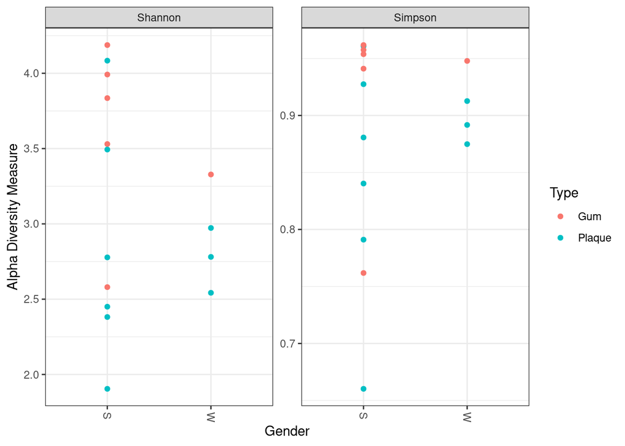

```r
plot_richness(ps, x="Gender", measures=c("Shannon", "Simpson"), color="Type")
```

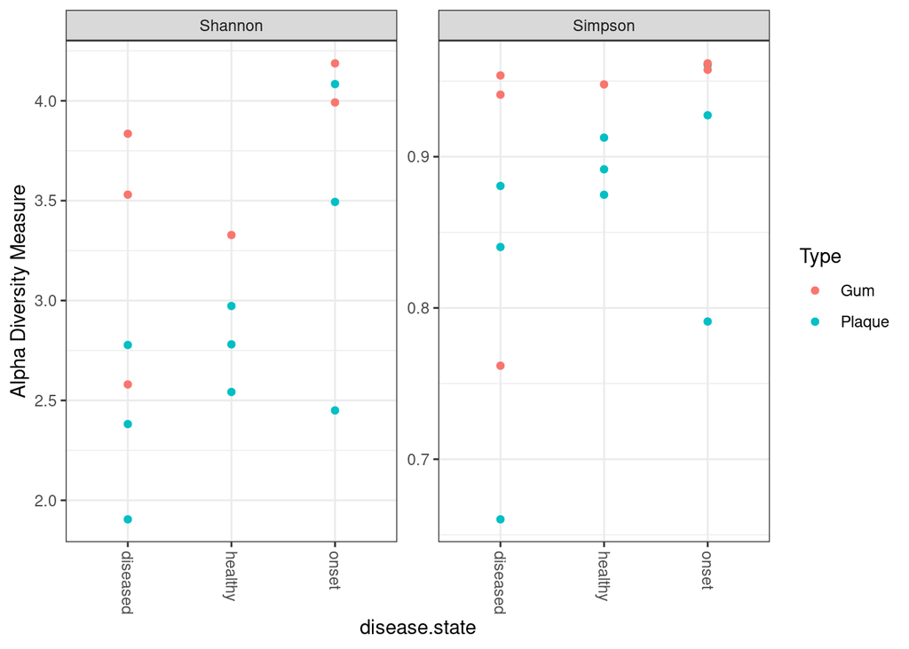

```r
plot_richness(ps, x="disease.state", measures=c("Shannon", "Simpson"), color="Type")
```

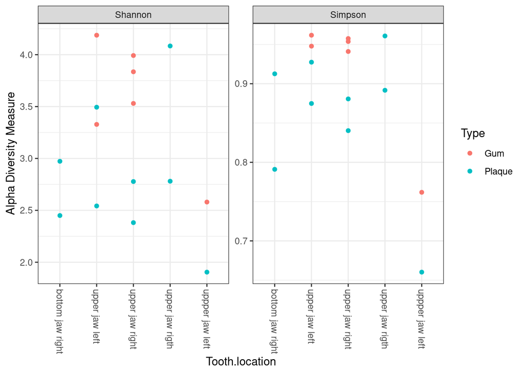

```r
plot_richness(ps, x="Tooth.location", measures=c("Shannon", "Simpson"), color="Type")
```

```r
# Transform data to proportions as appropriate for Bray-Curtis distances
ps.prop <- transform_sample_counts(ps, function(otu) otu/sum(otu))
ord.nmds.bray <- ordinate(ps.prop, method="NMDS", distance="bray")
```

```
## *** Best solution repeated 5 times
```

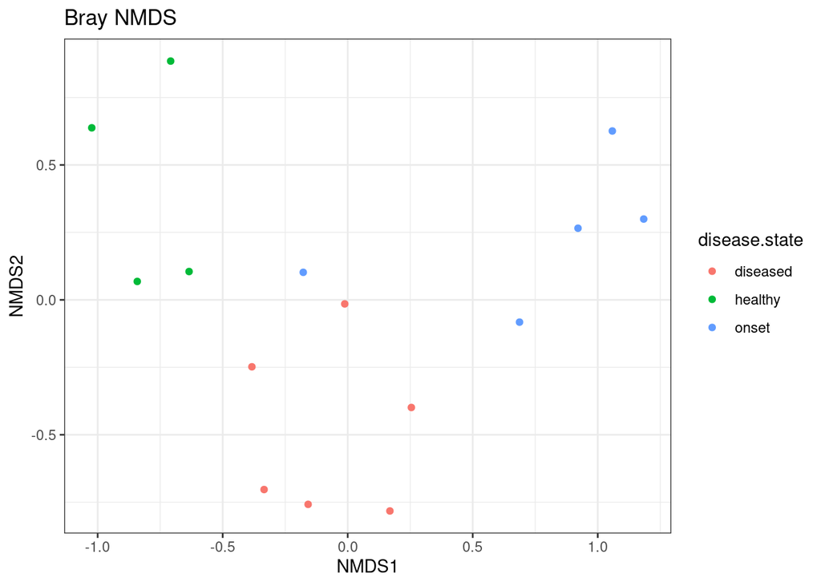

```r
plot_ordination(ps.prop, ord.nmds.bray, color="disease.state", title="Bray NMDS")
```

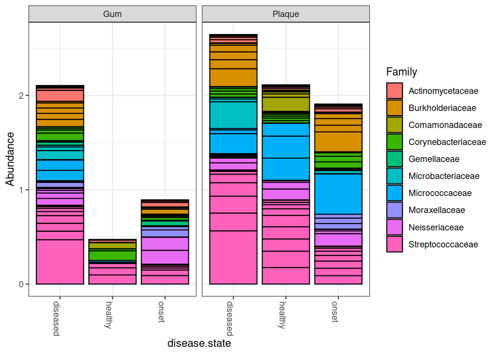

```r
top20 <- names(sort(taxa_sums(ps), decreasing=TRUE))[1:20]  # most
ps.top20 <- transform_sample_counts(ps, function(OTU) OTU/sum(OTU))
ps.top20 <- prune_taxa(top20, ps.top20)
plot_bar(ps.top20, x="disease.state", fill="Family") + facet_wrap(~Type, scales="free_x")
```

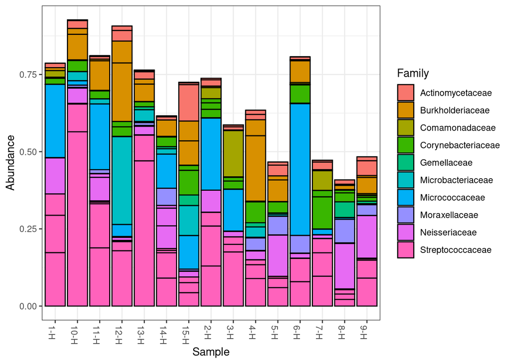

```r
plot_bar(ps.top20, fill = "Family")
```

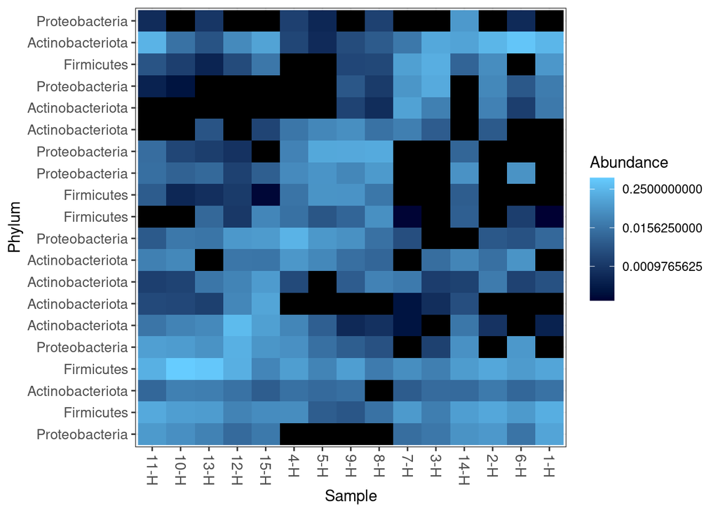

```r
plot_heatmap(ps.top20, taxa.label="Phylum") # only top 20 ASVs
```